# File S2

# Now see if there is a relationship between indel rate and kmer mutation rate, indel data are also from Ness et al. (2015) Genome Research.

```r
indelrates <- read.delim("~/Documents/AndyLab/Chlamy/RobData/MA_indelrate.txt")
indelrates
```

```
##      MA_line indel.rate
## 1   CC1373_1 3.5600e-10
## 2  CC1373_10 4.0900e-10
## 3  CC1373_11 4.1800e-10
## 4  CC1373_13 1.1400e-10
## 5  CC1373_14 7.2800e-10
## 6  CC1373_15 3.2178e-10
## 7   CC1373_2 2.5400e-10
## 8   CC1373_3 2.0500e-10
## 9   CC1373_4 1.6600e-10
## 10  CC1373_5 2.8700e-10
## 11  CC1373_6 2.9100e-10
## 12  CC1373_7 3.8300e-10
## 13  CC1373_8 2.6200e-10
## 14  CC1952_1 6.1900e-11
```

[output cut: 71 more lines]

```r
nrow(indelrates)
```

```
## [1] 85
```

```r
to_exclude <- c(which(indelrates$MA_line=="CC1373_15"), which(indelrates$MA_line=="CC2342_1"), which(indelrates$MA_line=="CC2342_2"), which(indelrates$MA_line=="CC2342_14"))
indelrates <- indelrates[-to_exclude,]

line_names <- as.vector(indelrates[,1])
line_names
```

```
##  [1] "CC1373_1"  "CC1373_10" "CC1373_11" "CC1373_13" "CC1373_14"
##  [6] "CC1373_2"  "CC1373_3"  "CC1373_4"  "CC1373_5"  "CC1373_6"
## [11] "CC1373_7"  "CC1373_8"  "CC1952_1"  "CC1952_10" "CC1952_11"
## [16] "CC1952_12" "CC1952_13" "CC1952_14" "CC1952_15" "CC1952_2"
## [21] "CC1952_3"  "CC1952_4"  "CC1952_5"  "CC1952_6"  "CC1952_7"
## [26] "CC1952_8"  "CC2342_10" "CC2342_11" "CC2342_12" "CC2342_13"
## [31] "CC2342_15" "CC2342_3"  "CC2342_4"  "CC2342_5"  "CC2342_7"
## [36] "CC2342_8"  "CC2342_9"  "CC2344_1"  "CC2344_10" "CC2344_11"
## [41] "CC2344_12" "CC2344_13" "CC2344_14" "CC2344_15" "CC2344_2"
## [46] "CC2344_3"  "CC2344_4"  "CC2344_5"  "CC2344_6"  "CC2344_7"
## [51] "CC2344_8"  "CC2344_9"  "CC2931_1"  "CC2931_10" "CC2931_11"
## [56] "CC2931_12" "CC2931_13" "CC2931_14" "CC2931_15" "CC2931_2"
## [61] "CC2931_3"  "CC2931_4"  "CC2931_5"  "CC2931_6"  "CC2931_7"
## [66] "CC2931_9"  "CC2937_1"  "CC2937_10" "CC2937_11" "CC2937_12"
## [71] "CC2937_13" "CC2937_14" "CC2937_15" "CC2937_2"  "CC2937_3"
## [76] "CC2937_4"  "CC2937_5"  "CC2937_6"  "CC2937_7"  "CC2937_8"
## [81] "CC2937_9"
```

```r
indelrates <- as.vector(indelrates[,2])
names(indelrates) <- line_names
indelrates
```

```
##  CC1373_1 CC1373_10 CC1373_11 CC1373_13 CC1373_14  CC1373_2  CC1373_3
##  3.56e-10  4.09e-10  4.18e-10  1.14e-10  7.28e-10  2.54e-10  2.05e-10
##  CC1373_4  CC1373_5  CC1373_6  CC1373_7  CC1373_8  CC1952_1 CC1952_10
##  1.66e-10  2.87e-10  2.91e-10  3.83e-10  2.62e-10  6.19e-11  4.94e-11
## CC1952_11 CC1952_12 CC1952_13 CC1952_14 CC1952_15  CC1952_2  CC1952_3
##  8.91e-11  6.33e-11  6.42e-11  4.76e-11  1.11e-10  9.63e-11  4.82e-11
##  CC1952_4  CC1952_5  CC1952_6  CC1952_7  CC1952_8 CC2342_10 CC2342_11
##  0.00e+00  2.19e-11  4.88e-11  8.81e-11  4.87e-11  6.97e-11  8.18e-11
## CC2342_12 CC2342_13 CC2342_15  CC2342_3  CC2342_4  CC2342_5  CC2342_7
##  3.59e-11  1.30e-10  1.06e-10  1.79e-10  1.32e-10  9.65e-11  2.33e-11
##  CC2342_8  CC2342_9  CC2344_1 CC2344_10 CC2344_11 CC2344_12 CC2344_13
##  7.18e-11  6.95e-11  7.35e-10  1.14e-10  7.39e-11  1.25e-10  1.25e-10
## CC2344_14 CC2344_15  CC2344_2  CC2344_3  CC2344_4  CC2344_5  CC2344_6
##  1.43e-10  1.83e-10  1.75e-10  1.46e-10  3.54e-11  2.17e-10  1.48e-10
##  CC2344_7  CC2344_8  CC2344_9  CC2931_1 CC2931_10 CC2931_11 CC2931_12
##  1.08e-10  1.17e-10  1.01e-10  1.54e-10  2.48e-10  1.47e-10  1.19e-09
## CC2931_13 CC2931_14 CC2931_15  CC2931_2  CC2931_3  CC2931_4  CC2931_5
##  1.83e-10  3.06e-10  9.53e-10  5.37e-10  1.86e-10  2.63e-10  9.43e-10
##  CC2931_6  CC2931_7  CC2931_9  CC2937_1 CC2937_10 CC2937_11 CC2937_12
##  2.80e-10  1.15e-10  1.94e-10  1.79e-10  2.24e-10  2.80e-11  1.16e-10
## CC2937_13 CC2937_14 CC2937_15  CC2937_2  CC2937_3  CC2937_4  CC2937_5
##  1.19e-10  1.56e-10  1.57e-10  9.50e-11  1.42e-10  2.23e-10  4.00e-11
##  CC2937_6  CC2937_7  CC2937_8  CC2937_9
##  1.57e-10  2.75e-11  1.60e-10  2.18e-10
```

```r
# break apart for each one, order them based on number
indelrates_1373 <- indelrates[grepl("CC1373", names(indelrates), fixed=FALSE)]
names(indelrates_1373) <- substr(names(indelrates_1373), start=8, stop=9)
indelrates_1373 <- indelrates_1373[order(as.integer(names(indelrates_1373)))]

indelrates_1952 <- indelrates[grepl("CC1952", names(indelrates), fixed=FALSE)]
names(indelrates_1952) <- substr(names(indelrates_1952), start=8, stop=9)
indelrates_1952 <- indelrates_1952[order(as.integer(names(indelrates_1952)))]

indelrates_2342 <- indelrates[grepl("CC2342", names(indelrates), fixed=FALSE)]
names(indelrates_2342) <- substr(names(indelrates_2342), start=8, stop=9)
indelrates_2342 <- indelrates_2342[order(as.integer(names(indelrates_2342)))]

indelrates_2344 <- indelrates[grepl("CC2344", names(indelrates), fixed=FALSE)]
names(indelrates_2344) <- substr(names(indelrates_2344), start=8, stop=9)
indelrates_2344 <- indelrates_2344[order(as.integer(names(indelrates_2344)))]

indelrates_2931 <- indelrates[grepl("CC2931", names(indelrates), fixed=FALSE)]
names(indelrates_2931) <- substr(names(indelrates_2931), start=8, stop=9)
indelrates_2931 <- indelrates_2931[order(as.integer(names(indelrates_2931)))]

indelrates_2937 <- indelrates[grepl("CC2937", names(indelrates), fixed=FALSE)]
names(indelrates_2937) <- substr(names(indelrates_2937), start=8, stop=9)
indelrates_2937 <- indelrates_2937[order(as.integer(names(indelrates_2937)))]

indelrates_all <- c(indelrates_1373, indelrates_1952, indelrates_2342, indelrates_2344, indelrates_2931, indelrates_2937)


names(SNMrates_all)
```

```
##  [1] "1"  "2"  "3"  "4"  "5"  "6"  "7"  "8"  "10" "11" "13" "14" "1"  "2"
## [15] "3"  "4"  "5"  "6"  "7"  "8"  "10" "11" "12" "13" "14" "15" "3"  "4"
## [29] "5"  "7"  "8"  "9"  "10" "11" "12" "13" "15" "1"  "2"  "3"  "4"  "5"
## [43] "6"  "7"  "8"  "9"  "10" "11" "12" "13" "14" "15" "1"  "2"  "3"  "4"
## [57] "5"  "6"  "7"  "9"  "10" "11" "12" "13" "14" "15" "1"  "2"  "3"  "4"
## [71] "5"  "6"  "7"  "8"  "9"  "10" "11" "12" "13" "14" "15"
```

```r
ancestor_names <- c(rep("CC-1373", times=12), rep("CC-1952", times=14), rep("CC-2342", times=11), rep("CC-2344", times=15), rep("CC-2931", times=14), rep("CC-2937", times=15) )
length(ancestor_names)
```

```
## [1] 81
```

```r
mus_comp <- data.frame(Ancestor=ancestor_names, SNM=SNMrates_all, kmer=mu_absnorm_perline_all, indel=indelrates_all )
colnames(mus_comp) <- c("Ancestor", "SNM", "kmer", "indel")

summary(lm(formula = indelrates_all ~ mu_absnorm_perline_all))
```

```
##
## Call:
## lm(formula = indelrates_all ~ mu_absnorm_perline_all)
##
## Residuals:
##        Min         1Q     Median         3Q        Max
## -1.974e-10 -1.162e-10 -5.855e-11  1.986e-11  9.920e-10
##
## Coefficients:
##                          Estimate Std. Error t value Pr(>|t|)
## (Intercept)             2.111e-10  6.156e-11   3.429 0.000967 ***
## mu_absnorm_perline_all -4.138e-08  1.725e-07  -0.240 0.811075
## ---
## Signif. codes:  0 '***' 0.001 '**' 0.01 '*' 0.05 '.' 0.1 ' ' 1
##
## Residual standard error: 2.149e-10 on 79 degrees of freedom
## Multiple R-squared:  0.0007276,  Adjusted R-squared:  -0.01192
## F-statistic: 0.05752 on 1 and 79 DF,  p-value: 0.8111
```

```r
cor.test(y=mu_absnorm_perline_all, x=indelrates_all )
```

```
##
##  Pearson's product-moment correlation
##
## data:  indelrates_all and mu_absnorm_perline_all
## t = -0.23984, df = 79, p-value = 0.8111
## alternative hypothesis: true correlation is not equal to 0
## 95 percent confidence interval:
##  -0.2438873  0.1925089
## sample estimates:
##         cor
## -0.02697435
```

```r
# no relationship at all with indel rates.
```

## Plot the relationship between repeat expansion/contraction rate and SNM, and indel mutation rates.

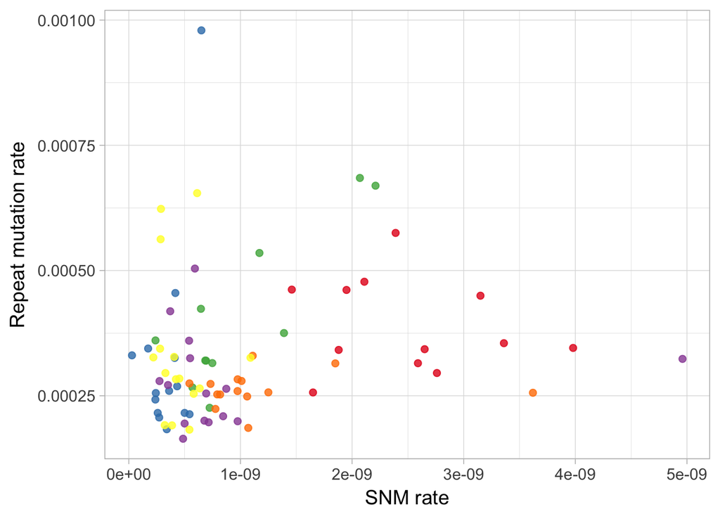

```r
ggplot(mus_comp, aes(color=Ancestor, x=SNM, y=kmer)) +
  geom_point(alpha=0.8, size=2) +
  ylab("Repeat mutation rate") +
  xlab("SNM rate") +
  theme_light(base_size = 14) +
  theme(legend.position="none") +
  scale_colour_brewer(palette = "Set1")
```

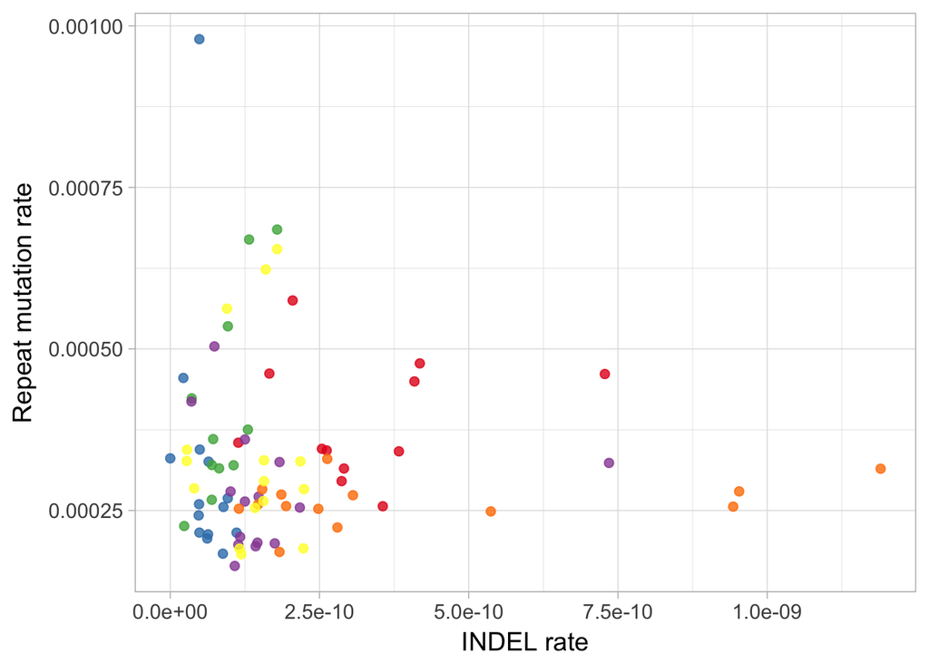

```r
ggplot(mus_comp, aes(color=Ancestor, x=indel, y=kmer)) +
  geom_point(alpha=0.8, size=2) +
  ylab("Repeat mutation rate") +
  xlab("INDEL rate") +
  theme_light(base_size = 14) +
  theme(legend.position="none") +
  scale_colour_brewer(palette = "Set1")
```

# Now look at the correlation in expansion and contraction of kmers across the MA lines of each ancestor  
Order the kmers by sequence relatedness, based on the relatedness network diagram (Figure 3 in manuscript)

```r
# which kmers to compare in network?
which(colnames(data_sorted)=="AAATTTATATACTCC")
```

```
## [1] 13
```

```r
# Look at the non-private kmers that are in the relatedness network
common.kmer.union.indexes_ordered <- c(3, 1, 17, 9, 28, 2, 24,5,16, 22, 35, 36, 37, 34, 48, 18, 12, 6, 4, 8, 33, 29, 19, 25, 14, 20, 27, 10, 23)

colnames(data_sorted)[common.kmer.union.indexes_ordered]
```

```
##  [1] "C"      "AC"     "ACC"    "AAC"    "ATC"    "AGC"    "AGG"
##  [8] "AAT"    "CCG"    "AGCGGC" "AGCGCC" "AGCGGG" "AGCCGC" "AGCCGG"
## [15] "AGGGGC" "AGGGC"  "AGGCGC" "AGGC"   "AGGCGG" "ACGC"   "ACGCC"
## [22] "ACGCCC" "ACCCGC" "ACCAGC" "ACCGGC" "ACAGGC" "ACAGGG" "ACACGC"
## [29] "AAAGT"
```

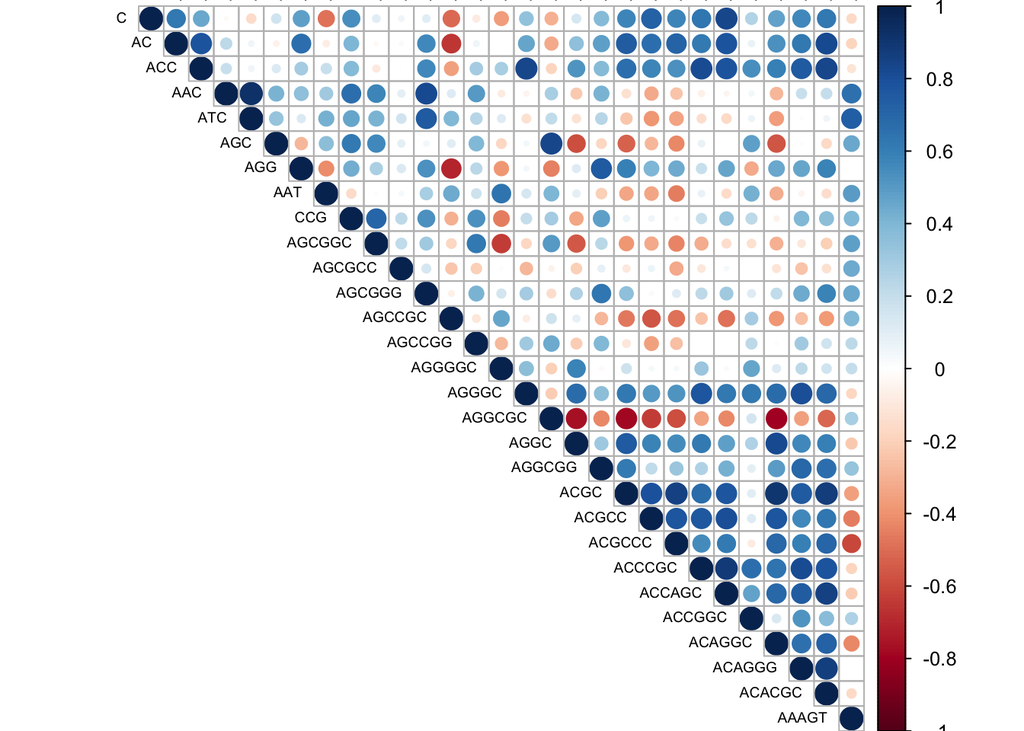

```r
# great, these are the indexes I want

par(mar=c(4,5,8,5))
kmer.union.deviation_1373 <- get_deviation(data_1373, common.kmer.union.indexes_ordered)
colnames(kmer.union.deviation_1373) <- colnames(data_sorted)[common.kmer.union.indexes_ordered]
mu.union_1373 <- kmer.union.deviation_1373/generations_1373
mucorr_1373 <- cor(mu.union_1373)
corrplot(mucorr_1373, type="upper", order="original", tl.col="black", tl.cex=0.6, tl.srt=90)
```

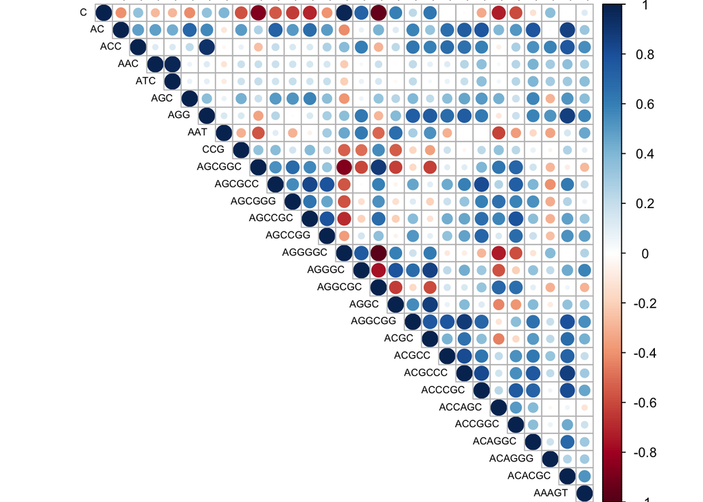

```r
kmer.union.deviation_1952 <- get_deviation(data_1952, common.kmer.union.indexes_ordered)
colnames(kmer.union.deviation_1952) <- colnames(data_sorted)[common.kmer.union.indexes_ordered]
mu.union_1952 <- kmer.union.deviation_1952/generations_1952
mucorr_1952 <- cor(mu.union_1952)
corrplot(mucorr_1952, type="upper", order="original", tl.col="black", tl.cex=0.6, tl.srt=90)
```

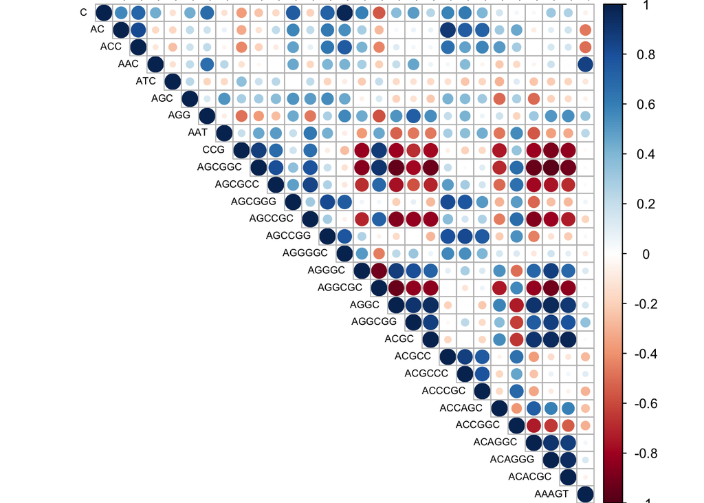

```r
kmer.union.deviation_2342 <- get_deviation(data_2342, common.kmer.union.indexes_ordered)
colnames(kmer.union.deviation_2342) <- colnames(data_sorted)[common.kmer.union.indexes_ordered]
mu.union_2342 <- kmer.union.deviation_2342/generations_2342
mucorr_2342 <- cor(mu.union_2342)
corrplot(mucorr_2342, type="upper", order="original", tl.col="black", tl.cex=0.6, tl.srt=90)
```

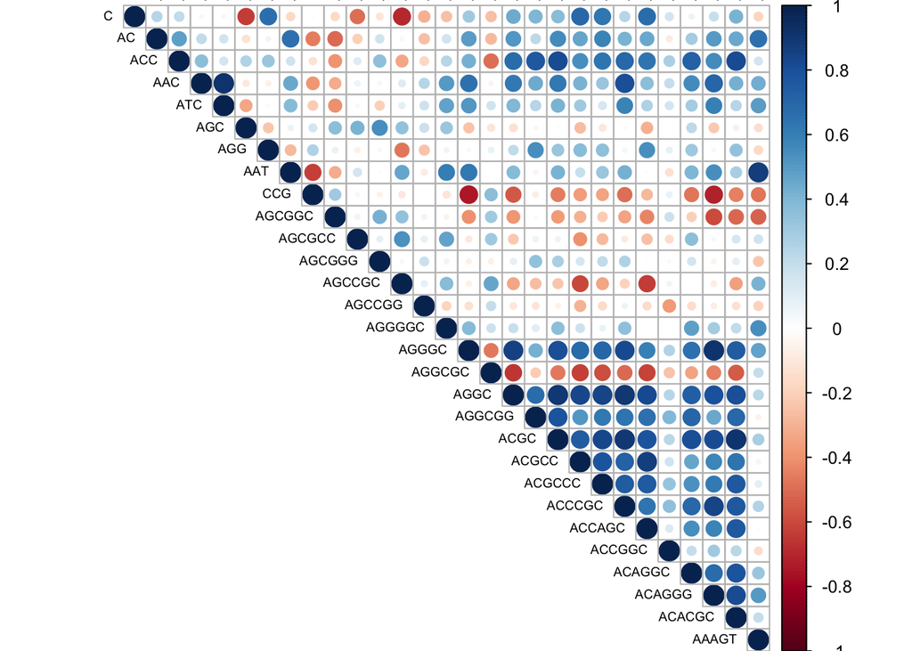

```r
kmer.union.deviation_2344 <- get_deviation(data_2344, common.kmer.union.indexes_ordered)
colnames(kmer.union.deviation_2344) <- colnames(data_sorted)[common.kmer.union.indexes_ordered]
mu.union_2344 <- kmer.union.deviation_2344/generations_2344
mucorr_2344 <- cor(mu.union_2344)
corrplot(mucorr_2344, type="upper", order="original", tl.col="black", tl.cex=0.6, tl.srt=90)
```

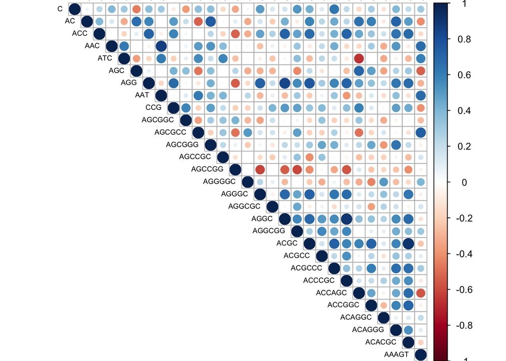

```r
kmer.union.deviation_2931 <- get_deviation(data_2931, common.kmer.union.indexes_ordered)
colnames(kmer.union.deviation_2931) <- colnames(data_sorted)[common.kmer.union.indexes_ordered]
mu.union_2931 <- kmer.union.deviation_2931/generations_2931
mucorr_2931 <- cor(mu.union_2931)
corrplot(mucorr_2931, type="upper", order="original", tl.col="black", tl.cex=0.6, tl.srt=90)
```

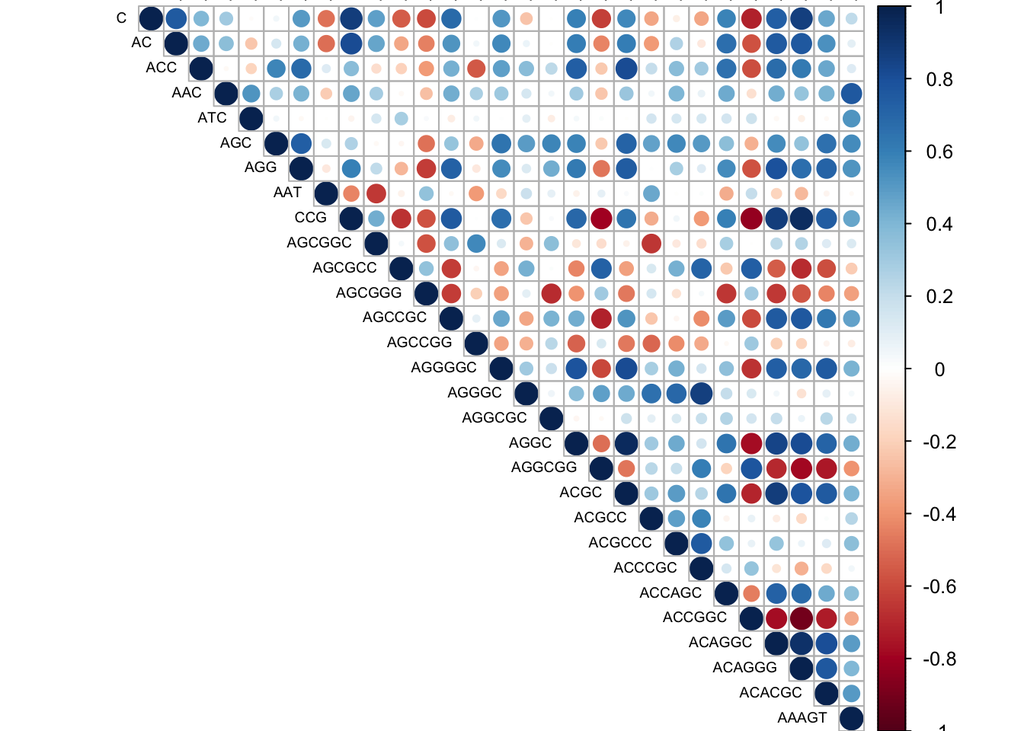

```r
kmer.union.deviation_2937 <- get_deviation(data_2937, common.kmer.union.indexes_ordered)
colnames(kmer.union.deviation_2937) <- colnames(data_sorted)[common.kmer.union.indexes_ordered]
mu.union_2937 <- kmer.union.deviation_2937/generations_2937
mucorr_2937 <- cor(mu.union_2937)
corrplot(mucorr_2937, type="upper", order="original", tl.col="black", tl.cex=0.6, tl.srt=90)
```